# Reproducible Data Analysis using R

Part 2: Data Exploration with Tidyverse

# Course Outline

The aim is to cover a subset of R features to enable you to do data exploration.

### 1. Basics, base R

Only what is necessary for working with tabular data

### 2. Cleaning and summarising tabular data using **`tidyverse`**

This is a particular style, and there are alternatives

### 3. Data visualisation using **`ggplot`**

R base plotting is the very popular alternative; we do not focus on that

### 4. Exploratory data analysis practice

Examples showing data exploration workflow  
We will not get into inferential statistics

### 5. Spatial data visualisation

Simple maps using vector data

# What we are NOT covering

We are omitting some of the core parts of R as they are not necessary for the learning objective of this workshop. E.g.,

- Arrays, Matrices
- Base plotting
- Lists
- Environments
- Object oriented programming, classes
- Data table

# Tidy Data and Tidyverse

- In 2014, Statistician and R developer Hadley Wickham introduced the philosophy of tidy data and viewing data analysis as a deeply interconnected and iterative process.
- He has also created or inspired the creation of an ecosystem of R packages related to preparation, analysis or visualisation of tidy data sets. These are collectively called the **Tidyverse**.
- What Kind of Data is Tidy?
  - Each variable you measure should be in one column
  - Each different observation of that variable should be in a different row
  - There should be one table for each “kind” of variable
  - If you have multiple tables, they should include a column in the table that allows them to be joined or merged  
    (source: https://github.com/jtleek/datasharing)

#### Tidyverse Tour: Great documentation and learning materials here: https://www.tidyverse.org/

# The Concept of a Data Processing Pipeline

Imagine we want to apply a sequence of operations on some data:

```
round(exp(mean(log(1:100))), 2)
```

This can become quite tedious to write and read as the number of operations increase. We could break it into steps:

```
a <- 1:100
b <- log(a)
c <- mean(b)
d <- exp(c)
e <- round(d, 2)
e
```

Another way is to have a special pipeline operator - **`%>%`**. The analogy here is that the data flows through an assembly line that has multiple stages of processing.

```
1:100 %>% log() %>% mean() %>% exp() %>% round(2)
```

Note that the data does not appear again and again in all the different functions. The **`%>%`** takes care of passing the processed data from each stage to the next one.

# Example

```r
library(dplyr)
library(stringr)

data <- tibble(
  x = 1:10,
  y = x^2
)
```

```r
data <- data %>%
  mutate(
    type = if_else(x %% 2 == 0, "even", "odd"),
    square_digits = str_length(y)
  )
```

```r
## Let's pick only even numbers with squares that have more than one digit
data %>%
  filter(type == "even" & square_digits > 1) %>%
  select(x, y)
```

```
## # A tibble: 4 x 2
##       x     y
##   <int> <dbl>
## 1     4    16
## 2     6    36
## 3     8    64
## 4    10   100
```

# Practice Time

`practice06_dplyr.Rmd`

`practice08_ua_wrangling.Rmd`

# Grammar of Graphics and ggplot

**`ggplot2`** package was implemented by Hadley Wickham following a systematic method (a “grammar”) to construct quantitative graphics, called [Grammar of Graphics](https://www.cs.uic.edu/~wilkinson/TheGrammarOfGraphics/GOG.html).

### At a high level, this is what you would do with ggplot:

1. create a plot with the `ggplot()` call
2. add layers using various `geom_*()` or `stat_*()` calls. Some properties (e.g. position) of these layers can be set in these calls.
3. specify “aesthetics” mapping using `aes()` for the full plot or per-layer. This deals with selecting the variables to plot, setting colours, sizes, shapes of the plot elements etc. Aesthetics can be “mapped” to variables in the data.
4. optionally specify faceting
5. optionally adjust the scale, the axes and the legend
6. optionally customise the theme

# Say Hello to `ggplot`

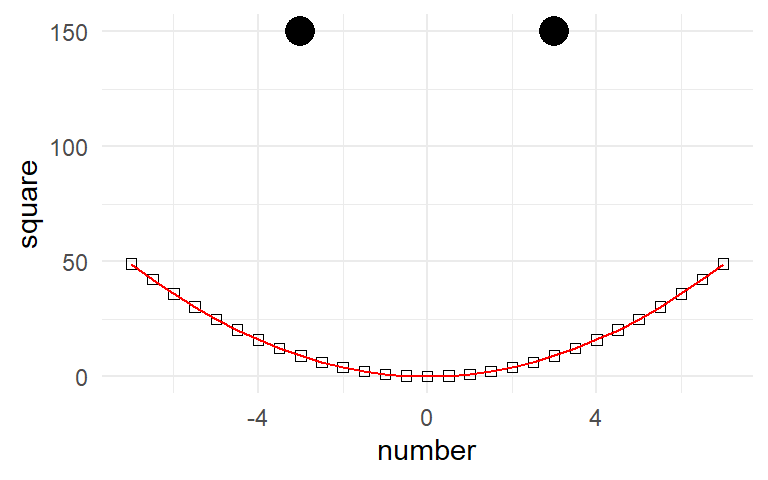

```r
library(dplyr)
library(ggplot2)

data <- tibble(
  number = seq(-7, 7, 0.5),
  square = number ^ 2,
)

ggplot(data) +
  geom_point(aes(x = number, y = square), shape = 0) +
  geom_line(aes(x = number, y = square), colour = "red") +
  geom_point(aes(x = -3, y = 150), size = 5) +
  geom_point(aes(x = 3, y = 150), size = 5) +
  theme_minimal()
```

# Practice Time

`practice07_ggplot.Rmd`

`practice09_ua_plot.Rmd`